# TEP_Exercicio2

Claudio Resende

06/05/2020

> PARTE I

# Situação problema 1

**Um administrador do ramo da saúde deseja estimar a probabilidade de um determinado paciente ter problemas relacionados ao coração. Para isso coletou uma amostra de seu banco de dados e resgatou pacientes que em algum momento, tiveram algum problema cardíaco. O objetivo é criar um modelo que pudesse indicar a probabilidade de um paciente vir a ter problemas cardíacos.**

## Hipóteses

Em vista dessa situação, um banco de dados foi criado com informações que supostamente estariam relacionadas com o problema.

- ID: Identificação do paciente
- Idade: Idade em anos do paciente
- Sexo: sexo do paciente
- IMC: Índice de massa corpórea do paciente
- Ccintura: circunferência da cintura (cm)
- Cquadril: circunferência do quadril (cm)
- frqCardiaca: frequência cardíaca (batimentos por minuto)
- fumo: Fuma :sim =1 ; não = 0
- atvFisica: frequência semanal de atividade física
- stress: Nível de Stress = escala de 1 (mínimo) a 4 (máximo)
- pdiasto: Pressão diastólica
- Doença Card: Problemas cardíacos (sim = 1 , não = 0)

## Análise

### I. Classifique cada varável envolvida no problema

- Idade: quantitativa discreta
- Sexo: qualitativa nominal
- IMC: quantitativa contínua
- Circunferência da cintura: quantitativa discreta
- Circunferência do quadril: quantitativa discreta
- Frequência cardíaca: quantitativa discreta
- Fumo: qualitativa ordinal
- Atividade física: quantitativa discreta
- Stress: qualitativa ordinal
- Pressão diastólica: quantitativa contínua
- Doença Cardíaca: qualitativa ordinal

### II. Realize uma análise descritiva para cada variável

#### Idade

```
##    Min. 1st Qu.  Median    Mean 3rd Qu.    Max.
##   16.00   19.00   21.00   23.14   25.00   63.00
```

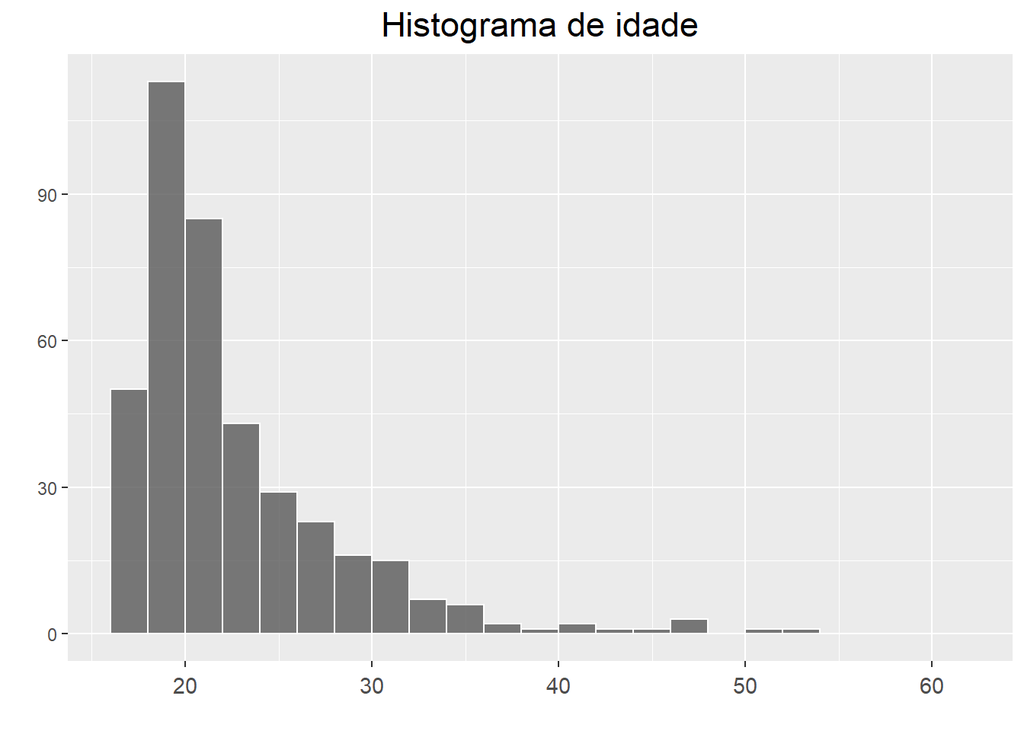

```r
ggplot(cardio, aes(x = idade)) +
        geom_histogram(breaks = seq(min(cardio$idade), max(cardio$idade), by = 2),
                       col = "white",
                       alpha = 0.8) +
        labs(title = "Histograma de idade",
             x = "", y = "") +
        theme(legend.title = element_blank(), plot.title = element_text(hjust = 0.5, size = 17),
              legend.text = element_text(size = 11),
              axis.text.x = element_text(size = 11, vjust = 0),axis.title = element_text(hjust = 0.5))
```

#### Sexo

```
##  Feminino Masculino
##       225       175
```

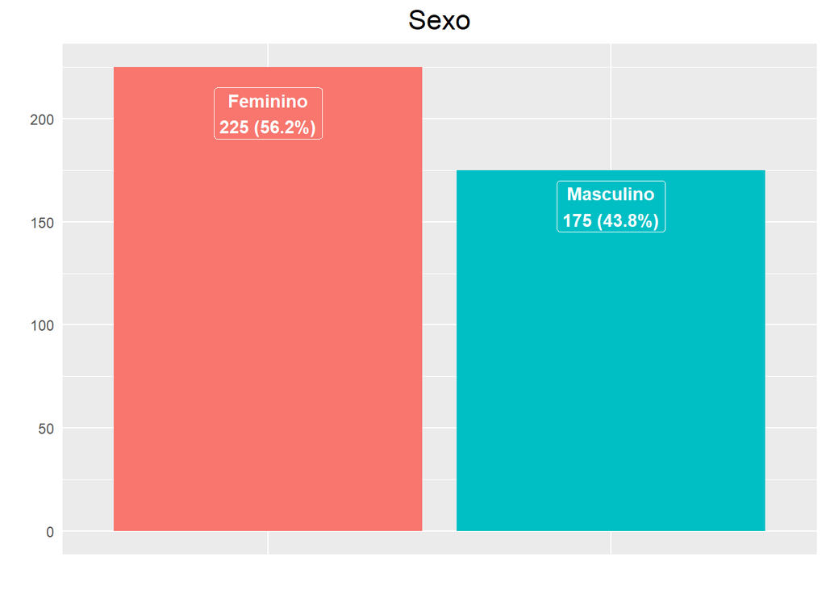

```r
cardio %>%
     group_by(sexo) %>% summarise(Total = n()) %>%
     mutate("%" = round(Total/sum(Total), digits = 3)*100) %>%
     ggplot(aes(x = sexo, y = Total, fill = sexo, label = paste0(sexo,"\n", Total," (", `%`, "%)"))) +
     geom_col() +
     labs(title = "Sexo",
          x = "", y = "") +
     geom_label(aes(y = Total), colour = "white", fontface = "bold", position = position_stack(vjust = 0.90)) +
     theme(legend.title = element_blank(), plot.title = element_text(hjust = 0.5, size = 17),
           legend.text = element_text(size = 11), axis.text.x = element_blank(),
           axis.ticks = element_blank(), legend.position = "none")
```